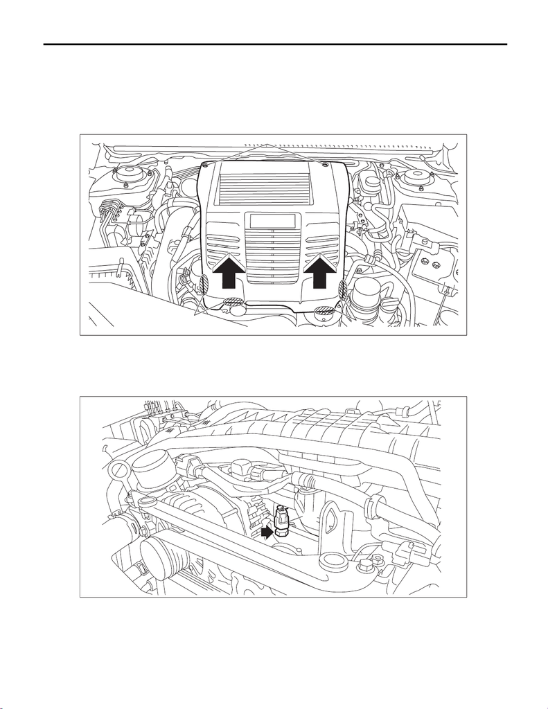

FU(w/o STI)-93

Engine Coolant Temperature Sensor

FUEL INJECTION (FUEL SYSTEMS)

11.Engine Coolant Temperature Sensor

A: REMOVAL

1) Remove the collector cover.

(1) Remove the clips (A).

(2) Hold the shaded area (B) by hand and carefully pull the RH side (C) upward.

(3) Hold the shaded area (D) by hand and carefully pull the LH side (E) upward.

2) Disconnect the ground terminal from battery sensor. <Ref. to NT-5, BATTERY, NOTE, Note.>

3) Drain engine coolant. <Ref. to CO(w/o STI)-13, DRAINING OF ENGINE COOLANT, REPLACEMENT,

Engine Coolant.>

4) Disconnect the connector (A) from the engine coolant temperature sensor, and remove the engine coolant

temperature sensor.

EX-03204

(A)

(B)

(C)

(E)

(D)

FU-08336

(A)

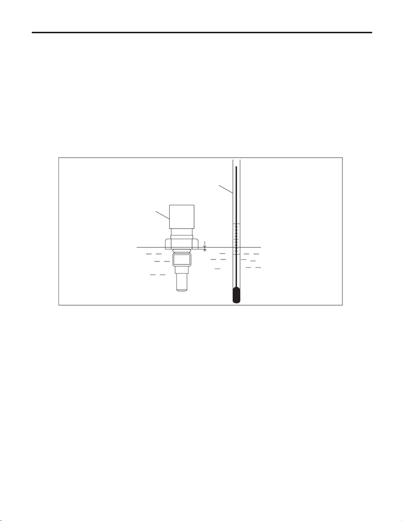

FU(w/o STI)-94

Engine Coolant Temperature Sensor

FUEL INJECTION (FUEL SYSTEMS)

B: INSTALLATION

Install in the reverse order of removal.

NOTE:

Use a new gasket.

Tightening torque:

18 N·m (1.8 kgf-m, 13.3 ft-lb)

C: INSPECTION

1) Check that the engine coolant temperature sensor has no deformation, cracks or other damages.

2) Immerse the engine coolant temperature sensor and a thermometer in water.

CAUTION:

Take care not to allow water to get into the engine coolant temperature sensor connector. Completely

remove any water inside.

(A) Thermometer (B) Engine coolant temperature sen-

sor

FU-05949

(A)

(B)

(C)

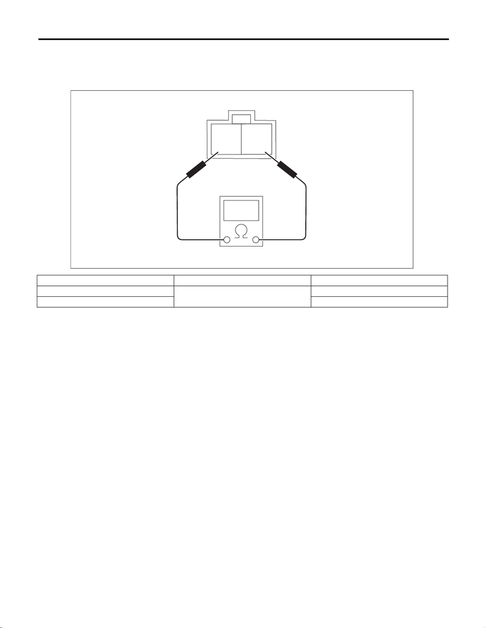

FU(w/o STI)-95

Engine Coolant Temperature Sensor

FUEL INJECTION (FUEL SYSTEMS)

3) Raise water temperature gradually, measure the resistance between the engine coolant temperature sen-

sor terminals when the temperature is 20°C (68°F) and 80°C (176°F).

NOTE:

Agitate the water for even temperature distribution.

Water temperature Terminal No. Standard

20°C (68°F)

1 and 2

Approx. 2.45±0.2 kΩ

80°C (176°F) Approx. 0.318±0.013 kΩ

FU-05950

2

1